# Bayesian Stats, Meeting 4

Adam Clark

2025-11-10

## Nested models

One of the most common uses of mixed effects models is to deal with “nested” data structures - e.g. cases where we have plots and subplots, and we want to control for potential autocorrelation in measurements across these different levels.

As an example, consider the following dataset:

```r
require(nlme)
```

```r
# Nested data example
set.seed(231011) # seed for analyses

error = 10 # residual error
n_plots = 30 # number of plots
n_subplots = 6 # subplots per block
intercepts_plots = sort(rnorm(n_plots, mean = 200, sd = 40)) # y-intercepts for each plot

intercepts_subplots = matrix(nrow = n_plots, ncol = n_subplots)
for(i in 1:n_plots) {
  intercepts_subplots[i,] = rnorm(n_subplots, mean = intercepts_plots[i], sd = 20) # intercept for each subplot
}

head(intercepts_subplots) # look at coefficient matrix
```

```
##           [,1]     [,2]     [,3]      [,4]     [,5]      [,6]
## [1,] 125.87778 158.6820 105.8007 143.48074 171.8825  99.89446
## [2,]  87.95432 126.8314 136.7150 125.74792 162.0472 122.14677
## [3,] 142.16306 130.6944 154.7805 157.81084 170.9102 165.15326
## [4,] 161.75433 153.1631 153.5505 177.32083 171.6685 144.05632
## [5,] 126.80925 136.9765 180.8973  99.78658 137.9795 149.41674
## [6,] 130.39626 135.8423 160.1018 164.90091 139.6939 133.25399
```

```r
bdat = NULL
for(j in 1:2) {
  # make fake data
  bdat_tmp = data.frame(plot = rep(1:n_plots, each = n_subplots),
                    subplot = 1:n_subplots,
                    biomass = NA)

  bdat_tmp$biomass = intercepts_subplots[cbind(bdat_tmp$plot, bdat_tmp$subplot)] + rnorm(n_plots*n_subplots, 0, error)

  bdat = rbind(bdat, bdat_tmp)
}
```

The result is a dataset of length 360 - i.e. two observations from each of 6 subplots in each of 30 plots (30x6x2 = 360).

Now, let’s first go ahead and fit *just* a model of plot-level effects. Before reading the code below, try writing out a version of this model yourself.

Note that we only are modelling mean biomass in each plot (i.e. the “intercepts”) rather than a relation with diversity. This will result in a “random effects model” - i.e. a mixed effects model with no fixed effects (other than the y-intercept). This is actually the kind of analysis for which mixed effects models were initially developed to conduct (e.g. for systems with lots of categorical predictor variables, such as differences in manufacturing outputs across employees in a big company).

```r
# Analyse data
mmod = lme(biomass ~ 1, data = bdat, random = ~1|plot)

summary(mmod)
```

```
## Linear mixed-effects model fit by REML
##   Data: bdat
##        AIC      BIC    logLik
##   3325.691 3337.341 -1659.846
##
## Random effects:
##  Formula: ~1 | plot
##         (Intercept) Residual
## StdDev:    43.47775 20.81692
##
## Fixed effects:  biomass ~ 1
##                Value Std.Error  DF  t-value p-value
## (Intercept) 198.6883  8.013377 330 24.79457       0
##
## Standardized Within-Group Residuals:
##         Min          Q1         Med          Q3         Max
## -2.63787504 -0.62671581  0.02218755  0.61874608  2.57184655
##
## Number of Observations: 360
## Number of Groups: 30
```

To fit a nested model that also includes subplot-level effects, we simply add another argument to the random effect term:

```r
# Analyse data
mmod2 = lme(biomass ~ 1, data = bdat, random = ~1|plot/subplot)

summary(mmod2)
```

```
## Linear mixed-effects model fit by REML
##   Data: bdat
##        AIC      BIC    logLik
##   3172.637 3188.171 -1582.319
##
## Random effects:
##  Formula: ~1 | plot
##         (Intercept)
## StdDev:    43.10078
##
##  Formula: ~1 | subplot %in% plot
##         (Intercept) Residual
## StdDev:    18.94391  10.3488
##
## Fixed effects:  biomass ~ 1
##                Value Std.Error  DF  t-value p-value
## (Intercept) 198.6883  8.013351 180 24.79465       0
##
## Standardized Within-Group Residuals:
##        Min         Q1        Med         Q3        Max
## -2.5422769 -0.4605163 -0.0159189  0.4670517  2.3753279
##
## Number of Observations: 360
## Number of Groups:
##              plot subplot %in% plot
##                30               180
```

```r
VarCorr(mmod2)
```

```
##             Variance     StdDev
## plot =      pdLogChol(1)
## (Intercept) 1857.6771    43.10078
## subplot =   pdLogChol(1)
## (Intercept)  358.8718    18.94391
## Residual     107.0977    10.34880
```

```r
VarCorr(mmod2)[,2] # look at standard deviations
```

```
##      plot = (Intercept)   subplot = (Intercept)    Residual
##          ""  "43.10078"          ""  "18.94391"  "10.34880"
```

## Model selection

Just like a regular OLS, we can compare mixed effects models using things like ANOVA or AIC. However, things are a bit different - in general, we need use a different fitting algorithm (“ML”, or “maximum likelihood”) when we are fitting models for the purpose of model comparison, and then return to the default fitting algorithm (“REML”, or “reduced maximum likelihood”) once we have identified the best model. Here’s an example of how to do so:

```r
# re-fit models
ML_mmod = update(mmod, method = "ML")
ML_mmod2 = update(mmod2, method = "ML")

# run ANOVA
anova(ML_mmod, ML_mmod2)
```

```
##          Model df      AIC      BIC    logLik   Test  L.Ratio p-value
## ML_mmod      1  3 3331.674 3343.333 -1662.837
## ML_mmod2     2  4 3178.620 3194.165 -1585.310 1 vs 2 155.0537  <.0001
```

The p-value is less than 0.05 - this suggests that the more complex model - mmod2 - adds significant explanatory power - i.e. that there is structuring of residuals at the subplot level (which we already knew since we simulated the data that way). Note that if we try to do the same analysis, but with some random extra variable that we know has no influence of the data:

```r
bdat$fake_subplot = sample(1:50, n_plots*n_subplots*2, replace = TRUE)

ML_mmod3 = lme(biomass ~ 1, data = bdat, random = ~1|plot/fake_subplot, method = "ML")

# run ANOVA
anova(ML_mmod, ML_mmod3)
```

```
##          Model df      AIC      BIC    logLik   Test      L.Ratio p-value
## ML_mmod      1  3 3331.674 3343.333 -1662.837
## ML_mmod3     2  4 3333.674 3349.219 -1662.837 1 vs 2 3.967616e-07  0.9995
```

we end up with p > 0.05 - i.e. the test tells us that there is no significant addition of information value to the model based on the additional fake_subplot data (which is encouraging…).

Remeber that once we’ve found our “best” model, we need to re-fit in order to interpret it:

```r
mmod2 = update(ML_mmod2, method = "REML")
summary(mmod2)
```

```
## Linear mixed-effects model fit by REML
##   Data: bdat
##        AIC      BIC    logLik
##   3172.637 3188.171 -1582.319
##
## Random effects:
##  Formula: ~1 | plot
##         (Intercept)
## StdDev:    43.10078
##
##  Formula: ~1 | subplot %in% plot
##         (Intercept) Residual
## StdDev:    18.94391  10.3488
##
## Fixed effects:  biomass ~ 1
##                Value Std.Error  DF  t-value p-value
## (Intercept) 198.6883  8.013351 180 24.79465       0
##
## Standardized Within-Group Residuals:
##        Min         Q1        Med         Q3        Max
## -2.5422769 -0.4605163 -0.0159189  0.4670517  2.3753279
##
## Number of Observations: 360
## Number of Groups:
##              plot subplot %in% plot
##                30               180
```

You can apply these test to all kinds of models. ANOVA apply for any nested set of models (i.e. models that differ in only a single random effect or a single fixed effect), whereas AIC can be applied for (most) any analyses that share the same response variables. Remember that for AIC, smaller values mean better fitting models (though also note that AIC can be under-conservative for big datas´ets). We’ll discuss more complex examples in later classes.´

## Your turn: Homework 2:

Try fitting different structures of models (combinations of fixed effect slopes and intercepts, and random effects vs. nested random effects).

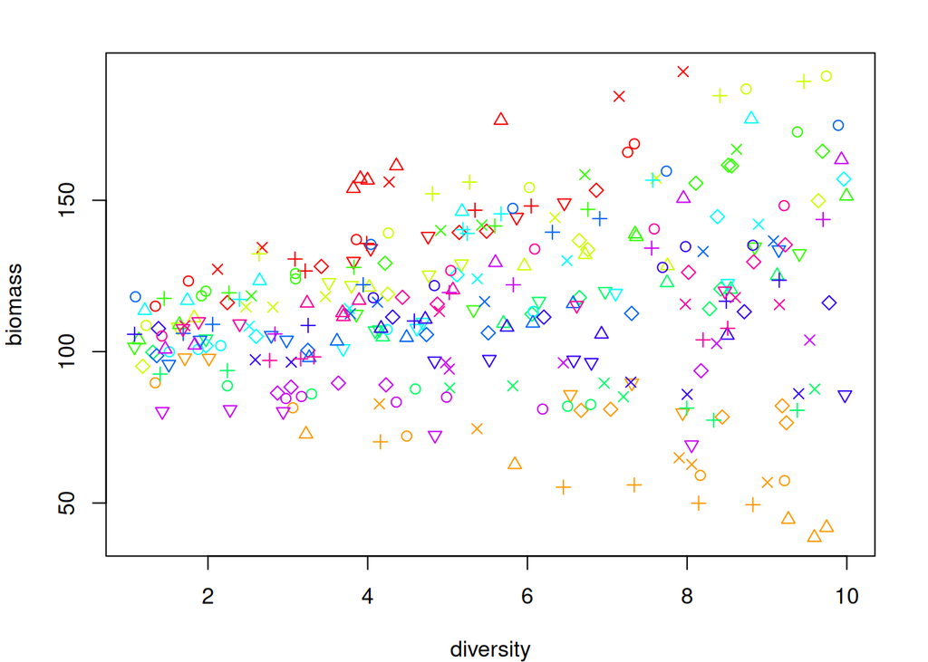

```r
bdat = read.csv("dataset_2.csv")
n_plots = length(unique(bdat$plot))

# plot
par(mar=c(4,4,2,2))
plot(biomass~diversity, col = rainbow(n_plots)[plot], pch = subplot, data = bdat)
```

Note - different point types show different subplots, and different colors show different plots. We can plot these trends a bit more informatively using the `coplot` command. It is set up similarly to the `lme` function (with some extra bits that we’ll discuss later).

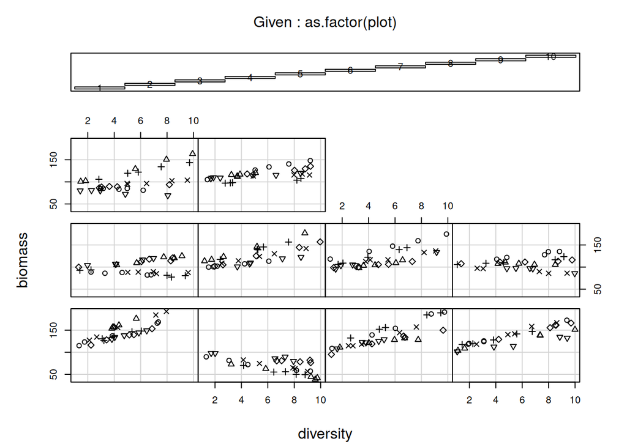

```r
par(mar=c(4,4,2,2))
coplot(biomass~diversity|as.factor(plot), data = bdat,
       panel = function(x, y, ...) {points(x,y, pch = bdat$subplot[bdat$plot==1])})
```

What form of regression should you use? Random slopes? Random intercepts? Nested? Something else?

What do the results of the regression show us? What are the fixed and random effects estimates? What is the variability across parameters?

## Next week:

Work through the datasets described here, and post any questions you have on the blog on the course website. In addition, try to find a “real-world” example of a dataset (e.g. from your research) that can be analysed using the tools we’ve discussed today, and try applying them. What model structure fits best? What does this structure hypothesise about the data? What do your results tell you?

We’ll discuss these points together in the coming weeks, so please be sure to write up your analyses in well-commented code, and to send them out over the blog.

Next time we meet, we’ll expand on the topics we’ve discussed this far using two additional packages: `lme4`, and `brms`.